# Variable Types, Standard Data Types & Data Type Conversion

```python
#Import library
from IPython.display import Image
```

## What are `variables` ?

- Variables are nothing but reserved memory locations to store values. It means that when you create a variable, you reserve some space in the memory.
- Based on the data type of a variable, the interpreter allocates memory and decides what can be stored in the reserved memory.
- Therefore, by assigning different data types to the variables, you can store integers, decimals or characters in these variables.

* Python variables do not need explicit declaration to reserve memory space.

* The declaration happens automatically when you assign a value to a variable.

* The equal sign (=) is used to assign values to variables.

## Note:

The **operand to the left** of the = operator is the **name of the variable** and the **operand to the right** of the = operator is **the value stored in the variable.**

```python
counter = 100 # An integer assignment

miles   = 1000.0 # A floating point

name    = "John" # A string

""" Here,   100,   1000.0   and   "John"   are   the   values   assigned   to
counter, miles, and name variables, respectively."""

print(counter)

print(miles)

print(name)
```

```
100
1000.0
John
```

## Multiple Assignment

##### Python allows you to assign a single value to several variables simultaneously.

```python
a = b = c = 1

"""Here, an integer object is created with the value 1,
and all the three variables are assigned to the same memory location."""

print(a)

print(b)

print(c)
```

```
1
1
1
```

##### You can also assign multiple objects to multiple variables.

```python
a, b, c = 1, 2, "john"

"""Here, two integer objects with values 1 and 2 are assigned to the variables a and b respectively,
and one string object with the value "john" is assigned to the variable c."""

print(a)

print(b)

print(c)
```

```
1
2
john
```

# Standard DataTypes

- **The data stored in memory can be of many types.**
  - For example,
    - a **person's age** is stored as a **numeric value**
    - and his or her **address** is stored as **alphanumeric characters.**
- Python has various standard data types that are used to define the operations possible on them and the storage method for each of them.

# Python has five standard data types-

> - ## Numbers
> - ## String
> - ## List
> - ## Tuple
> - ## Dictionary

### Note:

- **We can use the `type()` function to know which class a variable or a value belongs to.**
- **Similarly, the `isinstance()` function is used to check if an object belongs to a particular class.**

## Python Numbers

- Number data typesstore numeric values.
- Number objects are created when you assign a value to them.

```python
var1 = 1

var2 = 12.34

var3 = 1+2j

print(var1, 'is of type', type(var1))

print(var2, 'is of type', type(var2))

print(var3, 'is of type', type(var3))

print(var3, 'is a complex number?', isinstance(var3, complex)) #returns True or False
```

```
1 is of type <class 'int'>
12.34 is of type <class 'float'>
(1+2j) is of type <class 'complex'>
(1+2j) is a complex number? True
```

[output not shown]

del var1[,var2[,var3[....,varN]]]]

###### You can delete a single object or multiple objects by using the delstatement.

```python
del var1
```

```python
var1
```

```
---------------------------------------------------------------------------
NameError                                 Traceback (most recent call last)
<ipython-input-7-1b1d3752adce> in <module>
----> 1 var1

NameError: name 'var1' is not defined
```

```python
del var2, var3

print(var2, var3)
```

```
---------------------------------------------------------------------------
NameError                                 Traceback (most recent call last)
<ipython-input-8-65bc70fab246> in <module>
      1 del var2, var3
      2
----> 3 print(var2, var3)

NameError: name 'var2' is not defined
```

#### This way we can create and delete variables

## Python supports three different numerical type --

- ### int (signed integers)
- ### float (floating point real values)
- ### complex (complex numbers)

1. All integers in Python3 are represented as long integers. Hence, there is no separate number type as long.

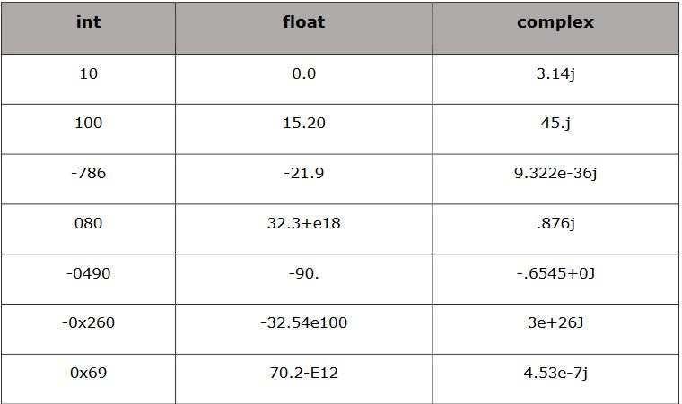

```python
"Here are some examples of numbers - "
Image('eg_numbers.JPG', width = 500, height = 700)
```

## Python Strings

### *Strings* in Python are identified as a contiguous set of characters represented in the quotation marks.

- Python allows either pair of **single ('') or double quotes("").**
  - **Subsets of strings can be taken using the slice operator ([ ] and [:]) with indexes starting at 0 in the beginning of the string and working their way from -1 to the end.**
  - The **plus (+)** sign is the **string concatenation operator**
  - and the **asterisk (*)** is the **repetition operator.**

```python
string = 'Hello! World of strings'

print(string)

print(string[5])

print(string[0:5])

print(string[:6])

print(string[7:])

print(string[:6] * 2)

print(string[:6] + ' ' + 'Veerendra')

print(string[:6] + string[7:])
```

```
Hello! World of strings
!
Hello
Hello!
World of strings
Hello!Hello!
Hello! Veerendra
Hello!World of strings
```

## Python Lists

- Lists are the most versatile of Python's compound data types. ### A list contains items separated by commas and enclosed within square brackets ([]).
- To some extent, **lists are similar to arrays in C.**
- *One of the differences between them is that **all the items belonging to a list can be of different data type.***

```python
list = [ 'abcd', 786 , 2.23, 'john', 70.2 ]

list
```

```
['abcd', 786, 2.23, 'john', 70.2]
```

- #### The values stored in a list can be accessed using the slice operator ([ ] and [:]) with indexes starting at 0 in the beginning of the list and working their way to end -1.

```python
print(list, '\n')          # Prints complete list

print(list[0], '\n')       # Prints first element of the list

print(list[1:3], '\n')     # Prints elements starting from 2nd till 3rd

print(list[2:], '\n')      # Prints elements starting from 3rd element
```

```
['abcd', 786, 2.23, 'john', 70.2]

abcd

[786, 2.23]

[2.23, 'john', 70.2]
```

- **The plus (+) sign is the list concatenation operator, and the asterisk(*) is the repetition operator.**

```python
tinylist = [123, 'john']

print (tinylist * 2)  # Prints list two times

print (list + tinylist) # Prints concatenated lists
```

```
[123, 'john', 123, 'john']
['abcd', 786, 2.23, 'john', 70.2, 123, 'john']
```

## Python Tuples

- A tuple is another sequence data type that is similar to the list.
- ### A tuple consists of a number of values separated by commas. Unlike lists, however, tuples are enclosed within parenthesis.

```python
tuple1 = ('abcd',786,2.23,'john',70.2)

tinytuple = (123,'john')

print(tuple1, '\n') #Prints complete tuple1

print(tuple1[0], '\n') #Prints first element of the tuple1

print(tuple1[1:3], '\n') #Prints elements starting from 2nd till 3rd

print(tuple1[2:], '\n') #Prints elements starting from 3rd element

print(tinytuple *2, '\n') #Prints tuple two times

print(tuple1 +tinytuple, '\n') #Prints concatenated tuple
```

```
('abcd', 786, 2.23, 'john', 70.2)

abcd

(786, 2.23)

(2.23, 'john', 70.2)

(123, 'john', 123, 'john')

('abcd', 786, 2.23, 'john', 70.2, 123, 'john')
```

## Main differene between List and Tuple.

> **>>>** *'Lists'* **are enclosed in brackets ( [ ] ) and their elements and size can be changed(***Mutable***),\ while** *'tuples'* **are enclosed in parentheses ( ( ) ) and cannot be updated(***Immutable***).**

> **>>> Tuples can be thought of as read-onlylists.**

```python
list[2]=1000 # Valid syntax with list
```

```python
tuple[2]=1000 # Invalid syntax with tuple
```

```
---------------------------------------------------------------------------
TypeError                                 Traceback (most recent call last)
<ipython-input-16-a2604d5fde9d> in <module>
----> 1 tuple[2]=1000 # Invalid syntax with tuple

TypeError: 'type' object does not support item assignment
```

## Python Dictionary

- **Python's dictionaries** are kind of hash-table type. They **work like associative arrays or hashes found in Perl** and **consist of key-value pairs.**
- A dictionary **key** can be almost **any Python type**, but are *usually numbers or strings.* **Values**, on the other hand, **can be any arbitrary Python object.**
- **Dictionaries are enclosed by curly braces ({ }) and values can be assigned and accessed using square braces ([ ]).**

```python
dict1 = {}  # declaring a dictionary with name dict

dict1['one' ] = "This is one."  # Key -> 'one'(string type) && Value -> "This is one." (string object)

dict1[2] = "This is two."  # Key -> 2(integer type) && Value -> "This is two." (string object)

#calling dictionary -> dict
dict1
```

```
{'one': 'This is one.', 2: 'This is two.'}
```

```python
tinydict ={'name':'john','code':6734,'dept':'sales'}

print(dict1['one'], '\n') # Prints value for 'one' key

print(dict1[2], '\n') # Prints value for 2 key

print(tinydict, '\n')# Prints complete dictionary

print(tinydict.keys(), '\n')# Prints all the keys

print(tinydict.values(), '\n')# Prints all the values
```

```
This is one.

This is two.

{'name': 'john', 'code': 6734, 'dept': 'sales'}

dict_keys(['name', 'code', 'dept'])

dict_values(['john', 6734, 'sales'])
```

### Note :

**Dictionaries have no concept of order among the elements. It is incorrect to say that the elements are "out of order"; they are simply unordered.**

# Data Type Conversion

- The process of converting the value of one data type (integer, string, float, etc.) to another data type is called type conversion. Python has two types of type conversion.
  1. Implicit Type Conversion
  2. Explicit Type Conversion

## Implicit Type Conversion

- In **Implicit type conversion**, *Python automatically converts one data type (smaller datatype) to another data type (lager data type) to avoid data loss.* This process doesn't need any user involvement.

**>>> Example 1: Converting integer to float**

```python
# Converting integer to float

num_int = 123   #int type
num_flo = 1.23  # float type

num_new = num_int + num_flo  #adding int to float

print("datatype of num_int:",type(num_int))
print("datatype of num_flo:",type(num_flo))

print("Value of num_new:",num_new)
print("datatype of num_new:",type(num_new))
```

```
datatype of num_int: <class 'int'>
datatype of num_flo: <class 'float'>
Value of num_new: 124.23
datatype of num_new: <class 'float'>
```

**In the above program,**

- We add two variables `num_int` and `num_flo`, storing the value in `num_new`.
- In the output, we can see the data type of `num_int` is an `integer` while the data type of `num_flo` is a `float`.
- Also, we can see the `num_new` has a `float` data type because Python always converts smaller data types to larger data types to avoid the loss of data.

**>>> Example 2: Addition of string(higher) data type and integer(lower) datatype**

```python
num_int = 123
num_str = "456"

print("Data type of num_int:",type(num_int))
print("Data type of num_str:",type(num_str))

print(num_int+num_str)
```

```
Data type of num_int: <class 'int'>
Data type of num_str: <class 'str'>
```

```
---------------------------------------------------------------------------
TypeError                                 Traceback (most recent call last)
<ipython-input-20-6e3c0f0ba491> in <module>
      5 print("Data type of num_str:",type(num_str))
      6
----> 7 print(num_int+num_str)

TypeError: unsupported operand type(s) for +: 'int' and 'str'
```

**In the above program,**

- We add two variables `num_int` and `num_str`.
- As we can see from the output, we got `TypeError`.

  > Python is not able to use Implicit Conversion in such conditions. However, Python has a solution for these types of situations which is known as **Explicit Conversion.**

## Explicit Type Conversion

- In **Explicit Type Conversion**, users convert the data type of an object to required data type. *We use the predefined functions like **int(), float(), str(), etc** to perform explicit type conversion.*
- This type of conversion is also called typecasting because the user casts(changes) the data type of the objects.
- **>>> Syntax: `<required_datatype>(expression)`**
- Typecasting can be done by assigning the required data type function to the expression.

**Example 3: Addition of string and integer using explicit conversion**

```python
num_int = 123  # int type
num_str = "456" # str type

print("Data type of num_int:",type(num_int))
print("Data type of num_str before Type Casting:",type(num_str))

num_str = int(num_str) #Type casting str to int

print("Data type of num_str after Type Casting:",type(num_str))

num_sum = num_int + num_str

print("Sum of num_int and num_str:",num_sum)
print("Data type of the sum:",type(num_sum))
```

```
Data type of num_int: <class 'int'>
Data type of num_str before Type Casting: <class 'str'>
Data type of num_str after Type Casting: <class 'int'>
Sum of num_int and num_str: 579
Data type of the sum: <class 'int'>
```

**In the above program,**

- We add `num_str` and `num_int` variable.
- We converted `num_str` from **string**(higher) to **integer**(lower) type using **int()** function to perform the addition.
- After converting `num_str` to an *integer* value, Python is able to add these two variables.
- We got the `num_sum` value and data type to be an **integer.**

#### Key Points to Remember:

1. **Type Conversion is conversion of object from one datatype to another datatype.**
2. **Implicit Type Conversion is automatically performed by Python interpreter.**
3. **Python avoids loss of data in Implicit Type Conversion.**
4. **Explicit Type Conversion is also called Type Casting, the data types of objects are converted using predefined functions by the user.**
5. **In Type casting, loss of data may occur as we enforce the object to a specific data type.**